### Nuovi casi

I nuovi casi (positivi al tampone, sia ospedalizzati che in isolamento domiciliare) sono 138. Rispetto al bilancio della giornata di ieri, il numero delle persone risultate positive al tampone in un solo giorno è aumentato (59 persone in più).

I pazienti positivi al COVID-19 (ospedalizzati + isolamento domiciliare) in Sicilia sono in totale 596.

### Isolamento domiciliare

Le persone positive al coronavirus in isolamento domiciliare sono 321. Rispetto a ieri, sono 117 le persone in più in isolamento domiciliare.

### Pazienti ospedalizzati

Il totale dei pazienti ospedalizzati è 275. Rispetto alla giornata di ieri, sono state ricoverate 21 persone in più. I pazienti ricoverati con sintomi sono 220. I ricoveri ospedalieri sono 14 in più rispetto a ieri. I pazienti ricoverati in terapia intensiva sono 55 (7 in più rispetto a ieri).

*Nelle ultime 24 ore*

| tamponi | nuovi positivi | isolamento domiciliare | ricoverati con sintomi | terapia intensiva |
| --- | --- | --- | --- | --- |
| 697 | 138 | 117 | 14 | 7 |

*In totale*

| tamponi | positivi | isolamento domiciliare | ricoverati con sintomi | terapia intensiva |
| --- | --- | --- | --- | --- |
| 5580 | 596 | 321 | 220 | 55 |

### Decessi

Nella giornata di oggi sono decedute 2 persone. Dall’inizio dell’epidemia sono decedute 8 persone. Il totale dei casi registrati di COVID-19 dall’inizio dell’epidemia è 630.

### Guariti

Sono guarite in totale 26 persone dall’inizio dell’epidemia.

*Nelle ultime 24 ore*

| deceduti | guariti |
| --- | --- |
| 2 | 0 |

*In totale*

| deceduti | guariti |
| --- | --- |
| 8 | 26 |

### Totale attualmente positivi - incidenza cumulativa

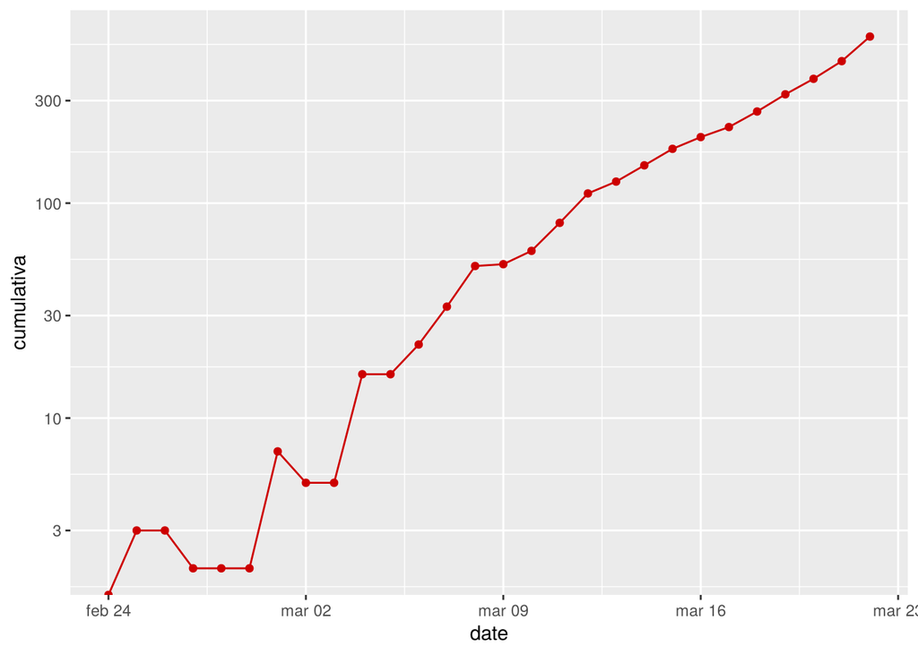

*[dati del Dipartimento della Protezione Civile](https://github.com/pcm-dpc/COVID-19) aggiornati al 2020-03-22 17:00:00*